# NZ GREEN Grid Household Electricity Demand Study: Data R Package

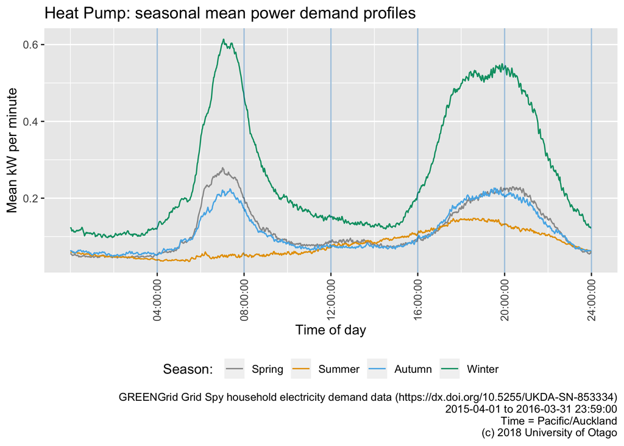

The Renewable Energy and the Smart Grid [(NZ GREEN Grid)](https://www.otago.ac.nz/centre-sustainability/research/energy/otago050285.html) project’s Household Electricity Demand Study data includes:

- 1 minute electricity power (W) data for c 40 households in NZ monitored from early 2014 using [gridSpy](https://gridspy.com/) monitors on each power circuit (and the incoming power)
- Occupant time-use diaries (focused on energy use)
- Dwelling & appliance surveys

This data has been cleaned and anonymised using the code in this [R package](https://github.com/CfSOtago/GREENGridData/) to produce the ‘safe’ dataset available from the [UK Data Service](http://reshare.ukdataservice.ac.uk/853334/). *None* of the data is held in the R package so *none* of the code here will work unless you also have access to the data.

# Accessing the data

The data is archived as:

- Anderson, Ben and Eyers, David and Ford, Rebecca and Giraldo Ocampo, Diana and Peniamina, Rana and Stephenson, Janet and Suomalainen, Kiti and Wilcocks, Lara and Jack, Michael (2018). [New Zealand GREEN Grid household electricity demand study 2014-2018](https://dx.doi.org/10.5255/UKDA-SN-853334). [Data Collection]. Colchester, Essex: UK Data Service. DOI: 10.5255/UKDA-SN-853334

You will need to register for a (free) UK Data Service account before you can download it. Despite appearances, users from outside the UK *can* register and download the data but will need to use a [specific form to request a UK Data Service user id](https://beta.ukdataservice.ac.uk/myaccount/credentials). Once registered you should be able to log in and download the data.

Please document any errors, problems or queries by raising a [github issue](https://github.com/CfSOtago/GREENGridData/issues) and we will try to respond.

# Terms of Use

This is *not* open access data. It is licensed as *Safeguarded* data under the [UK Data Archive End User Licence conditions](http://reshare.ukdataservice.ac.uk/legal/#Safeguarded). You will need to agree to these T&Cs before downloading the data.

# Version 1 - September 2018

Version 1 of the [data archive](https://dx.doi.org/10.5255/UKDA-SN-853334) includes:

- powerData.zip: 1 minute power demand data for each circuit in each household. One file per household;
- ggHouseholdAttributesSafe.csv.zip: anonymised household attribute data;
- checkPlots.zip:
  - simple line charts of mean power per month per year for each circuit monitored for each household. These are a useful check;
  - tile plots (heat maps/carpet plots) of the number of observations per hour per day. Also a useful check…
- PDF snapshots of the *live documentation* found below.

## Documentation

- Research data overview report;
- Household attribute data processing and documentation report;
- Household electricity demand data processing and documentation report;
- Household electricity demand outlier and negative power values report;
- Imputing total household demand:
  - Based on circuitsToSumv1.0.csv
  - Based on circuitsToSumv1.1.csv

> NB: Version 1 of the data package does not include any time-use diary data.

## Known Problems

- rf_15 & rf_17 grid spy files are in the archive but should not be. Users should remove them. [See further details…](https://github.com/CfSOtago/GREENGridData/issues/19)
- For others see our [issue list](https://github.com/CfSOtago/GREENGridData/issues?q=is%3Aissue+label%3AdataIssue)

# Accessing the code

The [GREEN Grid Data R Package](https://github.com/CfSOtago/GREENGridData) can be forked, cloned or installed as an R package. Amongst other things it contains the following folders: * *dataProcessing* - R scripts to process data and generate data quality reports. These will not run without access to the original study data but you can review them to understand why the anonymised data looks the way it does; * *docs* - the data archive documentation published via the [github pages](https://cfsotago.github.io/GREENGridData/) that you are now reading; * *examples* - R/Rmd script examples to show how the clean anonymised data can be analysed.

We encourage [feedback](https://github.com/CfSOtago/GREENGridData/issues) and [contributions](https://github.com/CfSOtago/GREENGridData/pulls) but inevitably #YMMV.

# Publications to date